# Regresión Lineal con variables cualitativas

# 1 Datos

```r
library(ISLR)
datos=Credit
str(datos)
```

```
## 'data.frame':    400 obs. of  12 variables:
##  $ ID       : int  1 2 3 4 5 6 7 8 9 10 ...
##  $ Income   : num  14.9 106 104.6 148.9 55.9 ...
##  $ Limit    : int  3606 6645 7075 9504 4897 8047 3388 7114 3300 6819 ...
##  $ Rating   : int  283 483 514 681 357 569 259 512 266 491 ...
##  $ Cards    : int  2 3 4 3 2 4 2 2 5 3 ...
##  $ Age      : int  34 82 71 36 68 77 37 87 66 41 ...
##  $ Education: int  11 15 11 11 16 10 12 9 13 19 ...
##  $ Gender   : Factor w/ 2 levels " Male","Female": 1 2 1 2 1 1 2 1 2 2 ...
##  $ Student  : Factor w/ 2 levels "No","Yes": 1 2 1 1 1 1 1 1 1 2 ...
##  $ Married  : Factor w/ 2 levels "No","Yes": 2 2 1 1 2 1 1 1 1 2 ...
##  $ Ethnicity: Factor w/ 3 levels "African American",..: 3 2 2 2 3 3 1 2 3 1 ...
##  $ Balance  : int  333 903 580 964 331 1151 203 872 279 1350 ...
```

# 2 Variables cualitativas con dos niveles

## 2.1 Variables auxiliares

Creamos una **variable auxiliar**, *mujer*, con los valores

- Mujer = 1, si Gender = Female
- Mujer = 0, si Gender = Male

```r
Mujer = as.numeric(datos$Gender == "Female")
```

El modelo estadístico que queremos estiamar es:

$$Balance = \beta_0 + \beta_1 Mujer + u$$

```r
m1 = lm(Balance ~ Mujer, data = datos)
summary(m1)
```

```
##
## Call:
## lm(formula = Balance ~ Mujer, data = datos)
##
## Residuals:
##     Min      1Q  Median      3Q     Max
## -529.54 -455.35  -60.17  334.71 1489.20
##
## Coefficients:
##             Estimate Std. Error t value Pr(>|t|)
## (Intercept)   509.80      33.13  15.389   <2e-16 ***
## Mujer          19.73      46.05   0.429    0.669
## ---
## Signif. codes:  0 '***' 0.001 '**' 0.01 '*' 0.05 '.' 0.1 ' ' 1
##
## Residual standard error: 460.2 on 398 degrees of freedom
## Multiple R-squared:  0.0004611,  Adjusted R-squared:  -0.00205
## F-statistic: 0.1836 on 1 and 398 DF,  p-value: 0.6685
```

El el fondo tenemos dos modelos, uno para los hombres y otro para las mujeres:

- Hombres (variable Mujer = 0): $Balance = \beta_0$ El crédito medio de los hombres es 509.80
- Mujeres (variable Mujer = 1): $Balance = \beta_0 + \beta_1$ El crédito medio de las mujeres es 509.80 + 19.73 = 529.53

## 2.2 Factores

Una manera más elegante de estimar estos modelos en R es utilizar una variable factor para representar la variable cualitativa:

```r
class(datos$Gender)
```

```
## [1] "factor"
```

```r
levels(datos$Gender)
```

```
## [1] " Male"  "Female"
```

Como *Gender* es de tipo factor, se puede hacer:

```r
m2 = lm(Balance ~ Gender, data = datos)
summary(m2)
```

```
##
## Call:
## lm(formula = Balance ~ Gender, data = datos)
##
## Residuals:
##     Min      1Q  Median      3Q     Max
## -529.54 -455.35  -60.17  334.71 1489.20
##
## Coefficients:
##              Estimate Std. Error t value Pr(>|t|)
## (Intercept)    509.80      33.13  15.389   <2e-16 ***
## GenderFemale    19.73      46.05   0.429    0.669
## ---
## Signif. codes:  0 '***' 0.001 '**' 0.01 '*' 0.05 '.' 0.1 ' ' 1
##
## Residual standard error: 460.2 on 398 degrees of freedom
## Multiple R-squared:  0.0004611,  Adjusted R-squared:  -0.00205
## F-statistic: 0.1836 on 1 and 398 DF,  p-value: 0.6685
```

Internamente, R asigna los valores:

```r
contrasts(datos$Gender)
```

```
##        Female
##  Male       0
## Female      1
```

## 2.3 Cambio de variable auxiliar

También se podía haber elegido como variable auxiliar la variable *Hombre*, con los valores

- Hombre = 0 si Gender = Female
- Hombre = 1, si Gender = Male

```r
Hombre = as.numeric(datos$Gender == " Male") # cuidado con el espacio
```

El modelo sería ahora:

$$Balance = \beta_0 + \beta_1 Hombre + u$$

```r
m3 = lm(Balance ~ Hombre, data = datos)
summary(m3)
```

```
##
## Call:
## lm(formula = Balance ~ Hombre, data = datos)
##
## Residuals:
##     Min      1Q  Median      3Q     Max
## -529.54 -455.35  -60.17  334.71 1489.20
##
## Coefficients:
##             Estimate Std. Error t value Pr(>|t|)
## (Intercept)   529.54      31.99  16.554   <2e-16 ***
## Hombre        -19.73      46.05  -0.429    0.669
## ---
## Signif. codes:  0 '***' 0.001 '**' 0.01 '*' 0.05 '.' 0.1 ' ' 1
##
## Residual standard error: 460.2 on 398 degrees of freedom
## Multiple R-squared:  0.0004611,  Adjusted R-squared:  -0.00205
## F-statistic: 0.1836 on 1 and 398 DF,  p-value: 0.6685
```

Es decir:

- Hombres (variable Hombre = 1): $Balance = \beta_0 + \beta_1$ El crédito medio de los hombres es 529.54 - 19.73 = 509.81
- Mujeres (variable Mujer = 1): $Balance = \beta_0$ El crédito medio de las mujeres es 529.54

Si estamos utilizando factores, tenemos que cambiar el orden de los niveles del factor:

```r
Gender1 = relevel(datos$Gender, ref = "Female")
levels(Gender1)
```

```
## [1] "Female" " Male"
```

```r
m4 = lm(datos$Balance ~ Gender1)
summary(m4)
```

```
##
## Call:
## lm(formula = datos$Balance ~ Gender1)
##
## Residuals:
##     Min      1Q  Median      3Q     Max
## -529.54 -455.35  -60.17  334.71 1489.20
##
## Coefficients:
##              Estimate Std. Error t value Pr(>|t|)
## (Intercept)    529.54      31.99  16.554   <2e-16 ***
## Gender1 Male   -19.73      46.05  -0.429    0.669
## ---
## Signif. codes:  0 '***' 0.001 '**' 0.01 '*' 0.05 '.' 0.1 ' ' 1
##
## Residual standard error: 460.2 on 398 degrees of freedom
## Multiple R-squared:  0.0004611,  Adjusted R-squared:  -0.00205
## F-statistic: 0.1836 on 1 and 398 DF,  p-value: 0.6685
```

## 2.4 Modelo sin ordenada en el origen

También se puede utilizar el modelo equivalente:

$$Balance = \beta_1 Hombre + \beta_2 Mujer + u$$

en el que se utilizan las dos variables auxiliares pero se elimina el parámetro $\beta_0$.

```r
m5 = lm(Balance ~ 0 + Hombre + Mujer, data = datos)
summary(m5)
```

```
##
## Call:
## lm(formula = Balance ~ 0 + Hombre + Mujer, data = datos)
##
## Residuals:
##     Min      1Q  Median      3Q     Max
## -529.54 -455.35  -60.17  334.71 1489.20
##
## Coefficients:
##        Estimate Std. Error t value Pr(>|t|)
## Hombre   509.80      33.13   15.39   <2e-16 ***
## Mujer    529.54      31.99   16.55   <2e-16 ***
## ---
## Signif. codes:  0 '***' 0.001 '**' 0.01 '*' 0.05 '.' 0.1 ' ' 1
##
## Residual standard error: 460.2 on 398 degrees of freedom
## Multiple R-squared:  0.5621, Adjusted R-squared:  0.5599
## F-statistic: 255.4 on 2 and 398 DF,  p-value: < 2.2e-16
```

Con factores:

```r
m6 = lm(datos$Balance ~ 0 + Gender, data = datos)
summary(m6)
```

```
##
## Call:
## lm(formula = datos$Balance ~ 0 + Gender, data = datos)
##
## Residuals:
##     Min      1Q  Median      3Q     Max
## -529.54 -455.35  -60.17  334.71 1489.20
##
## Coefficients:
##              Estimate Std. Error t value Pr(>|t|)
## Gender Male    509.80      33.13   15.39   <2e-16 ***
## GenderFemale   529.54      31.99   16.55   <2e-16 ***
## ---
## Signif. codes:  0 '***' 0.001 '**' 0.01 '*' 0.05 '.' 0.1 ' ' 1
##
## Residual standard error: 460.2 on 398 degrees of freedom
## Multiple R-squared:  0.5621, Adjusted R-squared:  0.5599
## F-statistic: 255.4 on 2 and 398 DF,  p-value: < 2.2e-16
```

# 3 Variable cualitativa con tres niveles

## 3.1 Variables auxiliares

En el caso de tener variables cualitativas con más de dos niveles:

```r
class(datos$Ethnicity)
```

```
## [1] "factor"
```

```r
levels(datos$Ethnicity)
```

```
## [1] "African American" "Asian"            "Caucasian"
```

Definimos las variables axiliares:

- Afro = 1 si Ethnicity = African American
- Asia = 1 si Ethnicity = Asian
- Cauc = 1 si Ethnicity = Caucasian

```r
Afro = as.numeric(datos$Ethnicity == "African American")
Asia = as.numeric(datos$Ethnicity == "Asian")
Cauc = as.numeric(datos$Ethnicity == "Caucasian")
```

Como la variable tiene tres niveles, necesitamos incluir dos variables auxiliares en el modelo estadístico:

Modelo general:

$$Balance = \beta_0 + \beta_1 Asia + \beta_2 Cauc + u$$

Modelo para “African American”: Asia = 0, Cauc = 0

$$Balance = \beta_0 + u$$

Modelo para “Asian”: Asia = 1, Cauc = 0

$$Balance = \beta_0 + \beta_1 + u$$

Modelo para “Caucasian”: Asia = 0, Cauc = 1

$$Balance = \beta_0 + \beta_2 + u$$
En R:

```r
m7 = lm(Balance ~ Asia + Cauc, data = datos)
summary(m7)
```

```
##
## Call:
## lm(formula = Balance ~ Asia + Cauc, data = datos)
##
## Residuals:
##     Min      1Q  Median      3Q     Max
## -531.00 -457.08  -63.25  339.25 1480.50
##
## Coefficients:
##             Estimate Std. Error t value Pr(>|t|)
## (Intercept)   531.00      46.32  11.464   <2e-16 ***
## Asia          -18.69      65.02  -0.287    0.774
## Cauc          -12.50      56.68  -0.221    0.826
## ---
## Signif. codes:  0 '***' 0.001 '**' 0.01 '*' 0.05 '.' 0.1 ' ' 1
##
## Residual standard error: 460.9 on 397 degrees of freedom
## Multiple R-squared:  0.0002188,  Adjusted R-squared:  -0.004818
## F-statistic: 0.04344 on 2 and 397 DF,  p-value: 0.9575
```

Utilizando factores se obtienen los mismos resultados:

```r
m8 = lm(Balance ~ Ethnicity, data = datos)
summary(m8)
```

```
##
## Call:
## lm(formula = Balance ~ Ethnicity, data = datos)
##
## Residuals:
##     Min      1Q  Median      3Q     Max
## -531.00 -457.08  -63.25  339.25 1480.50
##
## Coefficients:
##                    Estimate Std. Error t value Pr(>|t|)
## (Intercept)          531.00      46.32  11.464   <2e-16 ***
## EthnicityAsian       -18.69      65.02  -0.287    0.774
## EthnicityCaucasian   -12.50      56.68  -0.221    0.826
## ---
## Signif. codes:  0 '***' 0.001 '**' 0.01 '*' 0.05 '.' 0.1 ' ' 1
##
## Residual standard error: 460.9 on 397 degrees of freedom
## Multiple R-squared:  0.0002188,  Adjusted R-squared:  -0.004818
## F-statistic: 0.04344 on 2 and 397 DF,  p-value: 0.9575
```

Comprovamos que internamente R crea variables auxiliares según los valores:

```r
contrasts(datos$Ethnicity)
```

```
##                  Asian Caucasian
## African American     0         0
## Asian                1         0
## Caucasian            0         1
```

Podemos hacer otras comparaciones cambiando la variable de referencia:

```r
Ethnicity1 = relevel(datos$Ethnicity, ref="Asian")
levels(Ethnicity1)
```

```
## [1] "Asian"            "African American" "Caucasian"
```

```r
m9 = lm(Balance ~ Ethnicity1, data = datos)
summary(m9)
```

```
##
## Call:
## lm(formula = Balance ~ Ethnicity1, data = datos)
##
## Residuals:
##     Min      1Q  Median      3Q     Max
## -531.00 -457.08  -63.25  339.25 1480.50
##
## Coefficients:
##                            Estimate Std. Error t value Pr(>|t|)
## (Intercept)                 512.314     45.632  11.227   <2e-16 ***
## Ethnicity1African American   18.686     65.021   0.287    0.774
## Ethnicity1Caucasian           6.184     56.122   0.110    0.912
## ---
## Signif. codes:  0 '***' 0.001 '**' 0.01 '*' 0.05 '.' 0.1 ' ' 1
##
## Residual standard error: 460.9 on 397 degrees of freedom
## Multiple R-squared:  0.0002188,  Adjusted R-squared:  -0.004818
## F-statistic: 0.04344 on 2 and 397 DF,  p-value: 0.9575
```

Que en el fondo estamos haciendo:

```r
m10 = lm(Balance ~ Afro + Cauc, data = datos)
summary(m9)
```

```
##
## Call:
## lm(formula = Balance ~ Ethnicity1, data = datos)
##
## Residuals:
##     Min      1Q  Median      3Q     Max
## -531.00 -457.08  -63.25  339.25 1480.50
##
## Coefficients:
##                            Estimate Std. Error t value Pr(>|t|)
## (Intercept)                 512.314     45.632  11.227   <2e-16 ***
## Ethnicity1African American   18.686     65.021   0.287    0.774
## Ethnicity1Caucasian           6.184     56.122   0.110    0.912
## ---
## Signif. codes:  0 '***' 0.001 '**' 0.01 '*' 0.05 '.' 0.1 ' ' 1
##
## Residual standard error: 460.9 on 397 degrees of freedom
## Multiple R-squared:  0.0002188,  Adjusted R-squared:  -0.004818
## F-statistic: 0.04344 on 2 and 397 DF,  p-value: 0.9575
```

También podemos reordenar los niveles de la variable factor:

```r
Ethnicity2 = factor(datos$Ethnicity,levels=c("Caucasian","Asian","African American"))
levels(Ethnicity2)
```

```
## [1] "Caucasian"        "Asian"            "African American"
```

```r
m11 = lm(Balance ~ Ethnicity2, data = datos)
summary(m11)
```

```
##
## Call:
## lm(formula = Balance ~ Ethnicity2, data = datos)
##
## Residuals:
##     Min      1Q  Median      3Q     Max
## -531.00 -457.08  -63.25  339.25 1480.50
##
## Coefficients:
##                            Estimate Std. Error t value Pr(>|t|)
## (Intercept)                 518.497     32.670  15.871   <2e-16 ***
## Ethnicity2Asian              -6.184     56.122  -0.110    0.912
## Ethnicity2African American   12.503     56.681   0.221    0.826
## ---
## Signif. codes:  0 '***' 0.001 '**' 0.01 '*' 0.05 '.' 0.1 ' ' 1
##
## Residual standard error: 460.9 on 397 degrees of freedom
## Multiple R-squared:  0.0002188,  Adjusted R-squared:  -0.004818
## F-statistic: 0.04344 on 2 and 397 DF,  p-value: 0.9575
```

# 4 Variables cualitativas y cuantitativas

## 4.1 Modelo sin interacción

Es muy frecuente contar con regresores cualitativos y cuantitativos. Por ejemplo, vamos a estudiar la variable *Balance* en función de *Income* (cuantitativa) y *Student* (cualitativa). Definimos la variable auxiliar *Estudiante*

- Estudiante = 0: (Student = No)
- Estudiante = 1: (Student = Yes)

El modelo que vamos a analizar es:

$$Balance = \beta_0 + \beta_1 Income + \beta_2 Estudiante + u$$

Por tanto:

- Si Estudiante = 0: $Balance = \beta_0 + \beta_1 Income$
- Si Estudiante = 1: $Balance = (\beta_0 + \beta_2) + \beta_1 Income$

Tenemos dos rectas, **con la misma pendiente** y distinta $\beta_0$. En R:

```r
m12 = lm(Balance ~ Income + Student, data = datos)
summary(m12)
```

```
##
## Call:
## lm(formula = Balance ~ Income + Student, data = datos)
##
## Residuals:
##     Min      1Q  Median      3Q     Max
## -762.37 -331.38  -45.04  323.60  818.28
##
## Coefficients:
##             Estimate Std. Error t value Pr(>|t|)
## (Intercept) 211.1430    32.4572   6.505 2.34e-10 ***
## Income        5.9843     0.5566  10.751  < 2e-16 ***
## StudentYes  382.6705    65.3108   5.859 9.78e-09 ***
## ---
## Signif. codes:  0 '***' 0.001 '**' 0.01 '*' 0.05 '.' 0.1 ' ' 1
##
## Residual standard error: 391.8 on 397 degrees of freedom
## Multiple R-squared:  0.2775, Adjusted R-squared:  0.2738
## F-statistic: 76.22 on 2 and 397 DF,  p-value: < 2.2e-16
```

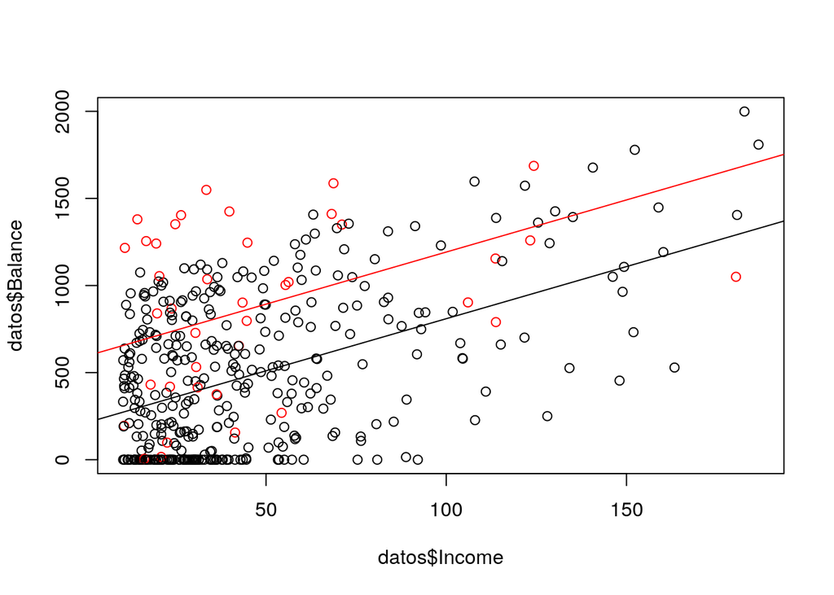

```r
plot(datos$Income, datos$Balance, col = datos$Student)
abline(m12$coefficients["(Intercept)"], m12$coefficients["Income"])
abline(m12$coefficients["(Intercept)"] + m12$coefficients["StudentYes"],
       m12$coefficients["Income"], col="red")
```

## 4.2 Modelo con interacción

¿Podemos representar con un único modelo dos rectas con distinta pendiente, una para estudiantes y otra para no estudiantes? Sea el modelo:

$$Balance = \beta_0 + \beta_1 Income + \beta_2 Estudiante + \beta_3 Estudiante Income + u$$

- Si Estudiante = 0: $Balance = \beta_0 + \beta_1 Income$
- Si Estudiante = 1: $Balance = (\beta_0 + \beta_2) + (\beta_1 + \beta_3) Income$

```r
m13 = lm(Balance ~ Income*Student, data = datos)
summary(m13)
```

```
##
## Call:
## lm(formula = Balance ~ Income * Student, data = datos)
##
## Residuals:
##     Min      1Q  Median      3Q     Max
## -773.39 -325.70  -41.13  321.65  814.04
##
## Coefficients:
##                   Estimate Std. Error t value Pr(>|t|)
## (Intercept)       200.6232    33.6984   5.953 5.79e-09 ***
## Income              6.2182     0.5921  10.502  < 2e-16 ***
## StudentYes        476.6758   104.3512   4.568 6.59e-06 ***
## Income:StudentYes  -1.9992     1.7313  -1.155    0.249
## ---
## Signif. codes:  0 '***' 0.001 '**' 0.01 '*' 0.05 '.' 0.1 ' ' 1
##
## Residual standard error: 391.6 on 396 degrees of freedom
## Multiple R-squared:  0.2799, Adjusted R-squared:  0.2744
## F-statistic:  51.3 on 3 and 396 DF,  p-value: < 2.2e-16
```

Según los resultados del análisis, las rectas tienen la misma pendiente.

La interacción en R también se define utilizando los dos puntos (:). Por tanto, el modelo anterior es equivalente a poner:

```r
m14 = lm(Balance ~ Income + Student + Income:Student, data = datos)
summary(m14)
```

```
##
## Call:
## lm(formula = Balance ~ Income + Student + Income:Student, data = datos)
##
## Residuals:
##     Min      1Q  Median      3Q     Max
## -773.39 -325.70  -41.13  321.65  814.04
##
## Coefficients:
##                   Estimate Std. Error t value Pr(>|t|)
## (Intercept)       200.6232    33.6984   5.953 5.79e-09 ***
## Income              6.2182     0.5921  10.502  < 2e-16 ***
## StudentYes        476.6758   104.3512   4.568 6.59e-06 ***
## Income:StudentYes  -1.9992     1.7313  -1.155    0.249
## ---
## Signif. codes:  0 '***' 0.001 '**' 0.01 '*' 0.05 '.' 0.1 ' ' 1
##
## Residual standard error: 391.6 on 396 degrees of freedom
## Multiple R-squared:  0.2799, Adjusted R-squared:  0.2744
## F-statistic:  51.3 on 3 and 396 DF,  p-value: < 2.2e-16
```

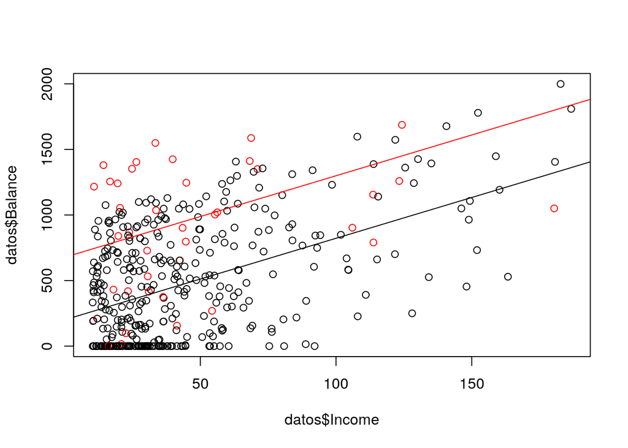

```r
plot(datos$Income, datos$Balance, col = datos$Student)
abline(m14$coefficients["(Intercept)"], m14$coefficients["Income"])
abline(m14$coefficients["(Intercept)"] + m14$coefficients["StudentYes"],
       m14$coefficients["Income"], col="red")
```

# 5 Más de una variable cualitativa

Sea el modelo que analiza la variable *Balance* en función de *Income*, *Gender* y *Ethnicity*. Recordamos que tenemos las variables auxiliares:

- Mujer = 1, si Gender = Female
- Mujer = 0, si Gender = Male
- Afro = 1, si Ethnicity = African American
- Asia = 1, si Ethnicity = Asian
- Cauc = 1, si Ethnicity = Caucasian

El primer modelo que podemos construir es:

$$Balance = \beta_0 + \beta_1 Income + \beta_2 Mujer + \beta_3 Asia + \beta_4 Cauc + u$$

| Gender | Ethnicity | Modelo |
| --- | --- | --- |
| Hombre | Afro | $Balance = \beta_0 + \beta_1 Income + u$ |
| Hombre | Asia | $Balance = (\beta_0 + \beta_3) + \beta_1 Income + u$ |
| Hombre | Cauc | $Balance = (\beta_0 + \beta_4) + \beta_1 Income + u$ |
| Mujer | Afro | $Balance = (\beta_0 + \beta_2) + \beta_1 Income + u$ |
| Mujer | Asia | $Balance = (\beta_0 + \beta_2 + \beta_3) + \beta_1 Income + u$ |
| Mujer | Cauc | $Balance = (\beta_0 + \beta_2 + \beta_4) + \beta_1 Income + u$ |

Como vemos, la pendiente $\beta_1$ que relaciona *Balance* e *Income* no depende del género ni de la raza. Sin embargo, la ordenada en el origen si depende de ambos factores de manera aditiva.

```r
m15 = lm(Balance ~ Income + Gender + Ethnicity, data = datos)
summary(m15)
```

```
##
## Call:
## lm(formula = Balance ~ Income + Gender + Ethnicity, data = datos)
##
## Residuals:
##     Min      1Q  Median      3Q     Max
## -794.14 -351.67  -52.02  328.02 1110.09
##
## Coefficients:
##                    Estimate Std. Error t value Pr(>|t|)
## (Intercept)        230.0291    53.8574   4.271 2.44e-05 ***
## Income               6.0542     0.5818  10.406  < 2e-16 ***
## GenderFemale        24.3396    40.9630   0.594    0.553
## EthnicityAsian       1.6372    57.7867   0.028    0.977
## EthnicityCaucasian   6.4469    50.3634   0.128    0.898
## ---
## Signif. codes:  0 '***' 0.001 '**' 0.01 '*' 0.05 '.' 0.1 ' ' 1
##
## Residual standard error: 409.2 on 395 degrees of freedom
## Multiple R-squared:  0.2157, Adjusted R-squared:  0.2078
## F-statistic: 27.16 on 4 and 395 DF,  p-value: < 2.2e-16
```

Podemos considerar interacciones entre el regresor cuantitativo y los cualitativos:

$$Balance = \beta_0 + \beta_1 Income + \beta_2 Mujer + \beta_3 Asia + \beta_4 Cauc + \beta_5 Mujer * Income + \beta_6 Asia * Income + \beta_7 Cauc * Income + u$$

| Gender | Ethnicity | Modelo |
| --- | --- | --- |
| Hombre | Afro | $Balance = \beta_0 + \beta_1 Income + u$ |
| Hombre | Asia | $Balance = (\beta_0 + \beta_3) + (\beta_1 + \beta_6) Income + u$ |
| Hombre | Cauc | $Balance = (\beta_0 + \beta_4) + (\beta_1 + \beta_7) Income + u$ |
| Mujer | Afro | $Balance = (\beta_0 + \beta_2) + (\beta_1 + \beta_5) Income + u$ |
| Mujer | Asia | $Balance = (\beta_0 + \beta_2 + \beta_3) + (\beta_1 + \beta_5 + \beta_6) Income + u$ |
| Mujer | Cauc | $Balance = (\beta_0 + \beta_2 + \beta_4) + (\beta_1 + \beta_5 + \beta_7) Income + u$ |

Es decir, tanto la pendiente como las ordenada en el origen dependen de los niveles de los factores. En R:

```r
m16 = lm(Balance ~ Income + Gender + Ethnicity + Income:Gender + Income:Ethnicity, data = datos)
summary(m16)
```

```
##
## Call:
## lm(formula = Balance ~ Income + Gender + Ethnicity + Income:Gender +
##     Income:Ethnicity, data = datos)
##
## Residuals:
##     Min      1Q  Median      3Q     Max
## -753.83 -357.12  -60.18  328.83 1100.00
##
## Coefficients:
##                           Estimate Std. Error t value Pr(>|t|)
## (Intercept)               150.4704    74.3670   2.023   0.0437 *
## Income                      7.7622     1.2337   6.292  8.4e-10 ***
## GenderFemale               47.5525    67.4646   0.705   0.4813
## EthnicityAsian             55.6196    92.2098   0.603   0.5467
## EthnicityCaucasian        124.8133    81.5912   1.530   0.1269
## Income:GenderFemale        -0.5773     1.2039  -0.480   0.6318
## Income:EthnicityAsian      -1.0723     1.5796  -0.679   0.4976
## Income:EthnicityCaucasian  -2.5669     1.3858  -1.852   0.0647 .
## ---
## Signif. codes:  0 '***' 0.001 '**' 0.01 '*' 0.05 '.' 0.1 ' ' 1
##
## Residual standard error: 408.9 on 392 degrees of freedom
## Multiple R-squared:  0.2228, Adjusted R-squared:  0.2089
## F-statistic: 16.05 on 7 and 392 DF,  p-value: < 2.2e-16
```

De igual forma se podrían añadir las interacciones *Gender:Ethnicity* y *Gender:Ethnicity:Income*, lo que añadiría nuevos términos al modelo.